# Quantile regression - introduction

Maciej Beręsewicz

# Packages

```r
library(quantreg) ## install.packages("quantreg")
library(data.table)
library(tidyverse)
library(lubridate)
```

# Data

```r
train <- fread("~/git/zbiory/otodom/train-small3.csv",
               col.names = c("id", "created_at_first", "category",
                             "is_business", "district_id", "city_id", "region_id",
                             "params", "title", "price")) %>%
  mutate(floor_area = str_extract(params, "m<=>\\d{1,}(\\.\\d{1,2})?"),
         floor_area = str_extract(floor_area, "\\d{1,}(\\.\\d{1,2})?"),
         floor_area = as.numeric(floor_area),
         rooms_num = str_extract(params, "rooms_num<=>\\d{1,}"),
         rooms_num = str_extract(rooms_num, "\\d{1,}"),
         rooms_num = as.numeric(rooms_num),created_at_first = ymd_hms(created_at_first),
         yq = quarter(created_at_first, with_year = T))

head(train)
```

|  | id | created_at_first | category | is_business | district_id | city_id | region_id | params | title | price | floor_area | rooms_num | yq |
| --- | --- | --- | --- | --- | --- | --- | --- | --- | --- | --- | --- | --- | --- |
| 1 | 883115 | 2018-10-11 22:05:15 | Mieszkanie na sprzedaż | 1 | 37 | 26 | 7 | price[currency]PLNm35rooms_num2marketprimarybuilding_typefloor_nofloor_1building_floors_num2building_materialwindows_typeheatingbuild_yearconstruction_statusto_completionrentpricerentrent[currency]PLN… | Idealne 2 pokojowe 35m2 z narożnym balkonem 10m2 | 246000 | 35.00 | 2 | 2018.4 |
| 2 | 980688 | 2018-07-11 09:30:50 | Mieszkanie na sprzedaż | 1 | NA | 934 | 7 | price[currency]PLNm58.8rooms_num3marketprimarybuilding_typeapartmentfloor_nofloor_3building_floors_num4building_materialotherwindows_typeheatingbuild_yearconstruction_statusto_completionrentpricerentr… | Duży balkon, dobrze doświetlone pomieszczenia! | 294000 | 58.80 | 3 | 2018.3 |
| 3 | 11062 | 2018-02-19 22:55:59 | Mieszkanie na sprzedaż | 0 | 300416 | 26 | 7 | price[currency]PLNm38rooms_num2marketsecondarybuilding_typeblockfloor_nofloor_3building_floors_numbuilding_materialbrickwindows_typeplasticheatingurbanbuild_yearconstruction_statusready_to_userentpric… | Świetnie położone 2-pok. mieszkanie - bezpośrednio | 479000 | 38.00 | 2 | 2018.1 |
| 4 | 877451 | 2018-08-25 19:05:42 | Mieszkanie na sprzedaż | 1 | 5 | 39 | 1 | price[currency]PLNm53.89rooms_num2marketprimarybuilding_typeblockfloor_noground_floorbuilding_floors_num2building_materialwindows_typeheatingbuild_year2018construction_statusrentpricerent6rent[currenc… | 2 pokoje, taras,ogródek - gotowa w 2018 roku | 274839 | 53.89 | 2 | 2018.3 |
| 5 | 13707 | 2018-03-22 13:33:32 | Mieszkanie na sprzedaż | 1 | 117 | 26 | 7 | price[currency]PLNm50.31rooms_num2marketsecondarybuilding_typetenementfloor_nofloor_1building_floors_num3building_materialbrickwindows_typeplasticheatingurbanbuild_year1952construction_statusrentprice… | Z balkonem; ciche; dużo zieleni | 449000 | 50.31 | 2 | 2018.1 |
| 6 | 894077 | 2018-02-07 08:05:14 | Mieszkanie na sprzedaż | 1 | 1320 | 38 | 6 | price[currency]PLNm36rooms_num2marketsecondarybuilding_typefloor_nofloor_2building_floors_numbuilding_materialwindows_typeheatingbuild_year1923construction_statusrentpricerent230rent[currency]PLNbuild… | ** Ciche \| Krakowskie Błonia \| Centrum ** | 333000 | 36.00 | 2 | 2018.1 |

```r
NA
```

# Quantile regression

## Introduction

In quantile regression we are interested in modelling the $\tau$ quantile of target $Y$ variable instead of mean.

More formally, any real valued random variable $Y$, may be characterized by its distribution function

$$F(y) = Prob(Y \leq y)$$

where for any $0 < \tau < 1$,

$$Q(\tau) = \inf\{y : F(y) \geq \tau \}$$

is called the $\tau$-th quantile of $Y$. The median, $Q(1/2)$, plays the central role. Like the distribution function, the quantile function provides a complete charicterization of the random variable $Y$.

The quantiles may be formulated as the solution to a simple optimization problem. For any $0 < \tau < 1$, define a picewise linear “check function”

$$\rho_\tau(u) = u (\tau - I( u < 0))$$

Minimizing the expectation of $\rho_\tau(Y-\xi)$ with respect to $\xi$ yelds solutions, $\hat{\xi}(\tau)$, the smallest of which is $Q(\tau)$ defined above.

The same analogue of $Q(\tau)$, based on a random sample, $\{y_1, y_2, ..., y_n \}$ of $Y$’s is called the $\tau$-th sample quantile, and may be found by solving

$$\min\limits_{\xi in \boldsymbol{R}} \sum_{i=1}^n \rho_\tau(y_i - \xi).$$

If we assume the linear conditional quantile function $Q_Y(\tau|X=x) = \boldsymbol{x}'_i\boldsymbol{\beta}$, we get

$$\hat{\beta}(\tau) = \operatorname{arg\,min}\limits_{\boldsymbol{\beta} in \boldsymbol{R}^p} \sum_{i=1}^n\rho_{\tau}(y_i- \boldsymbol{x}'_i\boldsymbol{\beta}).$$
## Quantile regression in R

The main package for quantile regression in R is `quantreg` which implements the following models

1. `quantreg::rq` – linear quantile regression
2. `quantreg::nlrq` – nonlinear quantile regression

## Example on real estate market

## linear regression

[output not shown]

```r
round(coef(model1),4)
```

```
                   (Intercept)                     floor_area                      rooms_num                    is_business
                   109374.7601                         0.0606                     82707.5517                     22119.2480
categoryMieszkanie na sprzedaż                     region_id2                     region_id3                     region_id4
                   -10063.5497                    -61316.6554                    -32804.0783                   -114014.0057
                    region_id5                     region_id6                     region_id7                     region_id8
                   -46719.0682                     68186.8769                    138562.1064                   -116739.8631
                    region_id9                    region_id10                    region_id11                    region_id12
                   -79665.5990                    -68737.0339                     64453.6376                    -84401.2662
                   region_id13                    region_id14                    region_id15                    region_id16
                   -57822.2161                    -74018.2971                     -7616.9516                    -11669.9556
```

## quantile regression

We will start with the median

```r
summary(model2)
```

```
21 non-positive fis
```

```
Call: rq(formula = price ~ floor_area + rooms_num + is_business + category +
    region_id, tau = 0.5, data = train)

tau: [1] 0.5

Coefficients:
                               Value         Std. Error    t value       Pr(>|t|)
(Intercept)                     139984.81681    5901.64513      23.71963       0.00000
floor_area                           0.09917       0.08132       1.21938       0.22271
rooms_num                        74999.34650     821.50485      91.29507       0.00000
is_business                      15001.42798    2920.78895       5.13609       0.00000
categoryMieszkanie na sprzedaż  -19988.60690    3986.06829      -5.01462       0.00000
region_id2                      -67378.13288    1951.66405     -34.52343       0.00000
region_id3                      -42229.04181    3927.34385     -10.75257       0.00000
region_id4                     -115002.66854    4873.68989     -23.59663       0.00000
region_id5                      -66004.63598    3384.75691     -19.50055       0.00000
region_id6                       39999.00835    2796.30915      14.30422       0.00000
region_id7                      104999.90083    2606.00458      40.29153       0.00000
region_id8                     -110000.59499   11623.81413      -9.46338       0.00000
region_id9                      -74729.11759    2875.40972     -25.98903       0.00000
region_id10                     -76000.04958    3630.17840     -20.93562       0.00000
region_id11                      24999.70250    3398.05292       7.35707       0.00000
region_id12                     -93834.56524    2598.96085     -36.10465       0.00000
region_id13                     -72154.56284    5810.50567     -12.41795       0.00000
region_id14                     -80002.61895    7385.62475     -10.83221       0.00000
region_id15                     -13377.04818    2881.23388      -4.64282       0.00000
region_id16                     -30002.62887    4438.95761      -6.75894       0.00000
```

```r
mean(sqrt(model1$residuals^2)) ## linear model
```

```
[1] 114438.8
```

```r
mean(sqrt(model2$residuals^2)) ## quantile model
```

```
[1] 111997.9
```

Quantile regression for other percentiles

```r
summary(model3)
```

```
1 non-positive fis1 non-positive fis21 non-positive fis
```

```
Call: rq(formula = price ~ floor_area + rooms_num + is_business + category,
    tau = c(0.25, 0.5, 0.75), data = train)

tau: [1] 0.25

Coefficients:
                               Value       Std. Error  t value     Pr(>|t|)
(Intercept)                    69982.31476 71708.93282     0.97592     0.32911
floor_area                         0.37620   957.01072     0.00039     0.99969
rooms_num                      57990.97116 19016.09953     3.04957     0.00229
is_business                    33990.59872  2975.12766    11.42492     0.00000
categoryMieszkanie na sprzedaż  3030.40086 65216.91064     0.04647     0.96294

Call: rq(formula = price ~ floor_area + rooms_num + is_business + category,
    tau = c(0.25, 0.5, 0.75), data = train)

tau: [1] 0.5

Coefficients:
                               Value        Std. Error   t value      Pr(>|t|)
(Intercept)                    107542.90213   6497.31655     16.55190      0.00000
floor_area                          0.29486      0.07647      3.85578      0.00012
rooms_num                       77483.34041   1100.26418     70.42249      0.00000
is_business                     26483.34041   3595.99204      7.36468      0.00000
categoryMieszkanie na sprzedaż  -2494.99198   4181.72141     -0.59664      0.55075

Call: rq(formula = price ~ floor_area + rooms_num + is_business + category,
    tau = c(0.25, 0.5, 0.75), data = train)

tau: [1] 0.75

Coefficients:
                               Value        Std. Error   t value      Pr(>|t|)
(Intercept)                    151236.67647   7427.83653     20.36080      0.00000
floor_area                          0.08222      0.12141      0.67715      0.49831
rooms_num                      103748.38651   1469.33267     70.60919      0.00000
is_business                     23750.04563   4712.83573      5.03944      0.00000
categoryMieszkanie na sprzedaż -12487.42916   4077.60643     -3.06244      0.00220
```

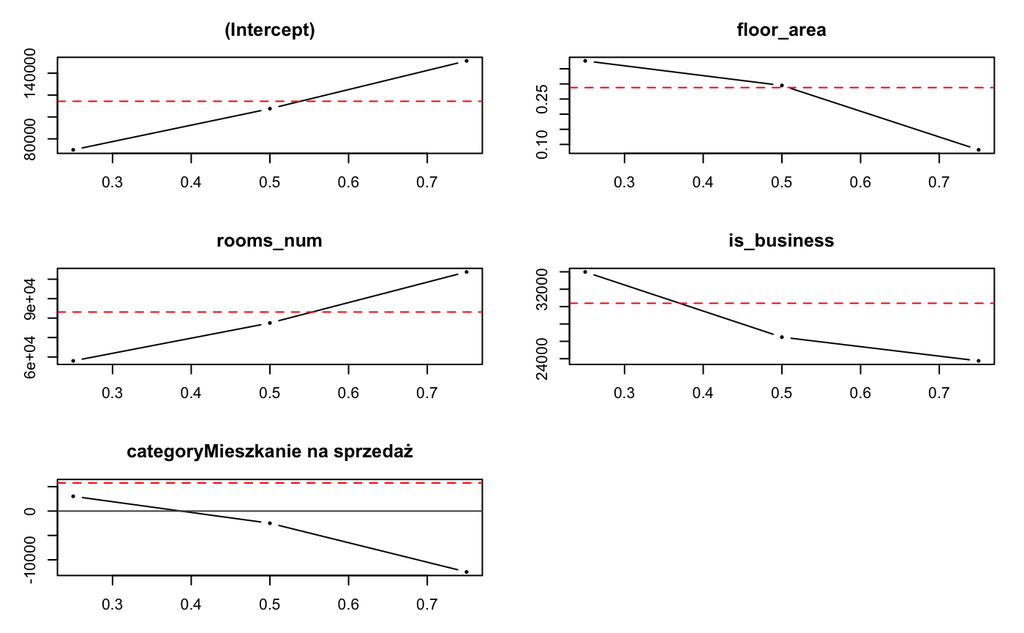

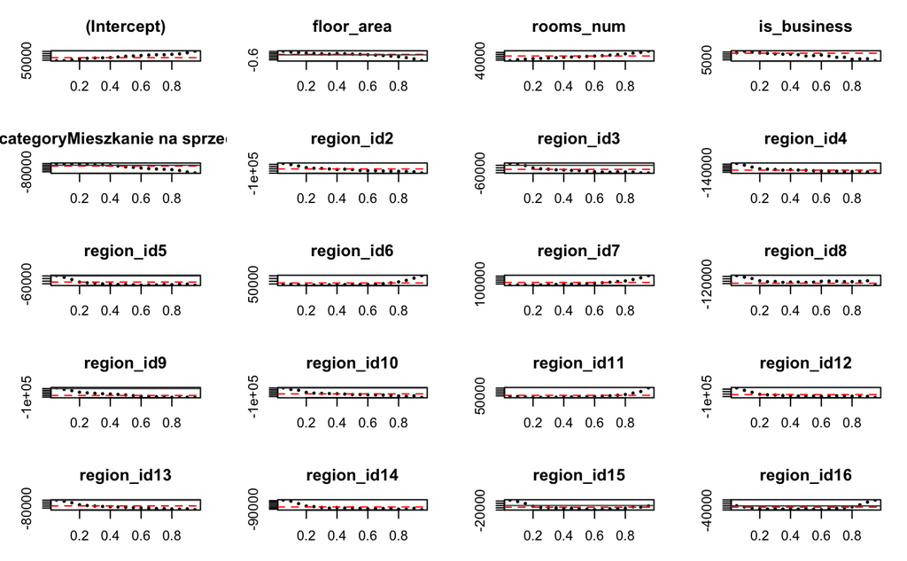

Extract coefficients

```r
coef(model4_result[[16]])
```

```
                                       Value   Std. Error    t value   Pr(>|t|)
(Intercept)                     1.837714e+05 8.503759e+03  21.610603 0.00000000
floor_area                     -2.227075e-01 1.511618e-01  -1.473305 0.14067926
rooms_num                       1.055657e+05 1.286966e+03  82.026804 0.00000000
is_business                     6.681549e+03 4.126006e+03   1.619375 0.10537720
categoryMieszkanie na sprzedaż -5.432989e+04 6.502536e+03  -8.355184 0.00000000
region_id2                     -8.280703e+04 4.244986e+03 -19.507021 0.00000000
region_id3                     -5.380664e+04 6.038276e+03  -8.910928 0.00000000
region_id4                     -1.312411e+05 1.071218e+04 -12.251582 0.00000000
region_id5                     -6.724221e+04 4.610396e+03 -14.584910 0.00000000
region_id6                      8.831794e+04 6.302522e+03  14.013110 0.00000000
region_id7                      1.783206e+05 4.101841e+03  43.473324 0.00000000
region_id8                     -1.038046e+05 5.581255e+03 -18.598796 0.00000000
region_id9                     -1.023760e+05 7.121768e+03 -14.375077 0.00000000
region_id10                    -9.280747e+04 3.178736e+03 -29.196347 0.00000000
region_id11                     8.619551e+04 8.517227e+03  10.120138 0.00000000
region_id12                    -9.679551e+04 2.905332e+03 -33.316506 0.00000000
region_id13                    -8.824566e+04 8.942377e+03  -9.868255 0.00000000
region_id14                    -8.975047e+04 7.641200e+03 -11.745599 0.00000000
region_id15                    -1.183520e+04 4.377377e+03  -2.703719 0.00686068
region_id16                    -9.350916e+03 8.854399e+03  -1.056076 0.29094209
```